# Arch Linux riscv64 on Android

This is an application emulating a headless riscv64 machine which runs an [Arch Linux](https://archlinux.org)operating system.

Arch Linux riscv64 Term is based on sources of [Termux](https://github.com/termux/termux-app) which is a terminal emulator for Android. Core of this application is the [QEMU](https://qemu.org) - a generic and open source machine emulator and virtualizer.

### Restrictions

- Application supports only AArch64 devices.
- Fixed amount of terminal sessions.
- Hardware acceleration like KVM is unsupported.
- Unprivileged user-mode networking only.

## User’s Guide

**Important**: this user’s guide does not include information about “how to use shell” or “how to use Arch Linux”. If you are new for such topics, it is recommended to read Bash Guide for Beginners and Advanced Bash-Scripting Guide.

- User interface
  - Main menu
  - Context menu
  - Navigation drawer
  - Notification
  - Extra keys row
  - Text input view
- Getting started
  - Terminal
  - Touch keyboard shortcuts
  - Hardware keyboard shortcuts
  - Settings
  - Exiting from application

### User interface

#### Main menu

On application’s cold start you will see a main menu. It allows to select a desired action you want to perform, for example launch virtual machine or open settings.

[figure not shown]

Description for menu entries:

- **Launch**

  Launch the virtual machine in normal mode.
- **Launch in sandbox mode**

  Launch the virtual machine in “sandbox” mode. All file system changes will not be saved in this mode.
- **Settings**

  Open application’s settings.
- **Help**

  Show the help page you reading now.
- **Exit**

  Exit the application.

Besides the main menu there are five additional interface elements available: a context menu, navigation drawer, notification, extra keys row and text input view. These additional elements become available when the virtual machine is running.

#### Context menu

The context menu can be shown by long pressing anywhere on the terminal. It provides menu entries for:

- Showing this help page.
- Choosing font and color scheme for styling the terminal.
- Selecting and pasting text.
- Sharing text from the terminal to other apps (e.g. email or SMS).
- Resetting the terminal if it gets stuck.
- A setting to control whether back key should send ESC.
- A setting to control whether bell characters should be ignored.

#### Navigation drawer

The navigation drawer is revealed by swiping inwards from the left part of the screen.

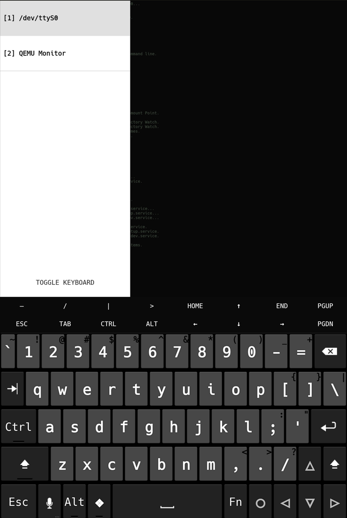

1. A list of sessions. Clicking on a session shows it in the terminal while long pressing allows you to specify a session title.
2. A button to toggle visibility of the touch keyboard. Long press will toggle extra keys row (3).

#### Notification

The notification shown while the Arch Linux riscv64 Term is running, is available by pulling down the status bar.

[figure not shown]

#### Extra keys row

The extra keys row provides some keys frequently required in shell sessions.

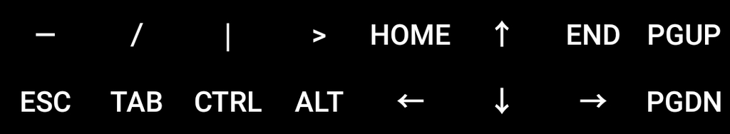

It can be toggled by: long-press on keyboard button located in the navigation drawer, by using a **Volume Up+Q** or **Volume Up+K** key combinations.

#### Text input view

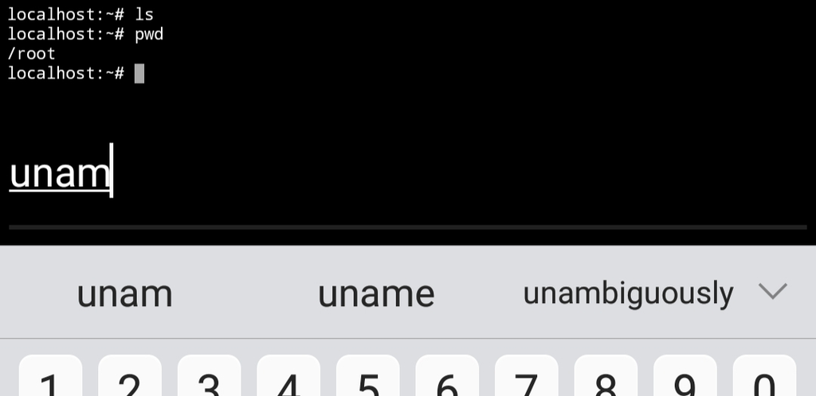

Terminal emulators usually do not support the advanced features of touch keyboards like autocorrection, prediction and swipe typing. To solve this, Arch Linux riscv64 Term has a text input view where all these features work correctly. Text entered in it will get pasted to the terminal. To access the text input view, swipe the extra keys row to the left side.

### Getting started

#### Terminal

Terminal is the important part of the Arch Linux riscv64 Term application. It provides a text-based interface to a shell of the operating system running inside the virtual machine.

When terminal is active, it is sensitive to taps and gestures. For example, pinch-zooming will change text size and short tap will act as mouse click. Long tap will toggle text selection and context menu.

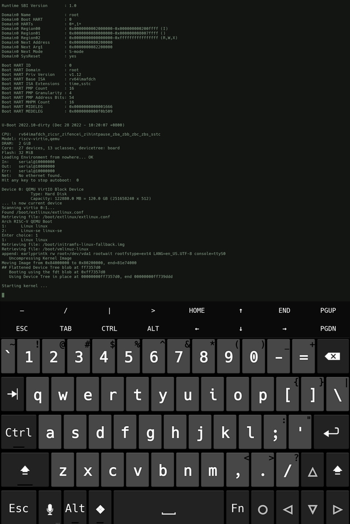

Arch Linux riscv64 Term uses a fixed number of terminal sessions, each of them has its own purpose. You cannot add new or remove existing ones.

The first session is serial console (ttyS0) which you can use to access the shell.

**Important**: serial console do not support automatic window resizing. Unfortunately this issue comes from the nature of serial console implementation and cannot be fixed. As workaround, it is suggested to call command ‘**resize**’ once you changed the window size.

The second session is a QEMU monitor. It gives you full control over QEMU’s internal state. If you want to learn about how to use QEMU monitor, read the QEMU documentation.

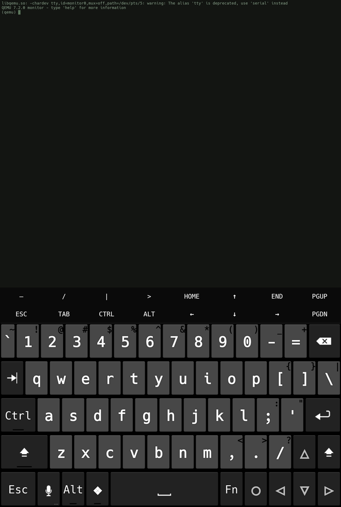

#### Touch keyboard shortcuts

Use of keys like Alt, Ctrl, Esc is necessary for working with many command line applications. Most of the Android touch keyboards do not include these keys.

The result of using **Ctrl** in combination with a key depends on which program is used, but for many command line tools the following shortcuts work:

- **Ctrl+A** → Move cursor to the beginning of line
- **Ctrl+C** → Abort (send SIGINT to) current process
- **Ctrl+D** → Logout of a terminal session
- **Ctrl+E** → Move cursor to the end of line
- **Ctrl+K** → Delete from cursor to the end of line
- **Ctrl+L** → Clear the terminal
- **Ctrl+Z** → Suspend (send SIGTSTP to) current process

**Volume Down** key used as Ctrl while the **Volume Up** key is used to to produce certain input on these key combinations:

- **Volume Up+.** → Ctrl+\ (SIGQUIT)
- **Volume Up+1** → F1 (and **Volume Up+2** → F2, etc)
- **Volume Up+0** → F10
- **Volume Up+A** → Left arrow key
- **Volume Up+B** → Alt+B, back a word when using readline
- **Volume Up+D** → Right arrow key
- **Volume Up+E** → Escape key
- **Volume Up+F** → Alt+F, forward a word when using readline
- **Volume Up+H** → ~ (the tilde character)
- **Volume Up+K** → Alias for **Volume Up+Q**
- **Volume Up+L** → | (the pipe character)
- **Volume Up+N** → Page Down
- **Volume Up+P** → Page Up
- **Volume Up+Q** → Toggle extra keys row
- **Volume Up+S** → Down arrow key
- **Volume Up+T** → Tab key
- **Volume Up+U** → _ (the underscore character)
- **Volume Up+V** → Show the volume control
- **Volume Up+W** → Up arrow key
- **Volume Up+X** → Alt+X

#### Hardware keyboard shortcuts

Following shortcuts in combination with **Ctrl+Alt** are available when using a hardware keyboard:

- **+/-** → Adjust text size
- **1-5** → Go to numbered session
- **M** → Show context menu
- **N** → Switch to next session
- **P** → Switch to previous session
- **R** → Rename current session
- **U** → Open URL selector
- **V** → Paste clipboard
- **Left arrow** → Close drawer
- **Right arrow** → Open drawer
- **Down arrow** → Alias for **N**
- **Up arrow** → Alias for **P**

#### Settings

You can enter settings via main menu.

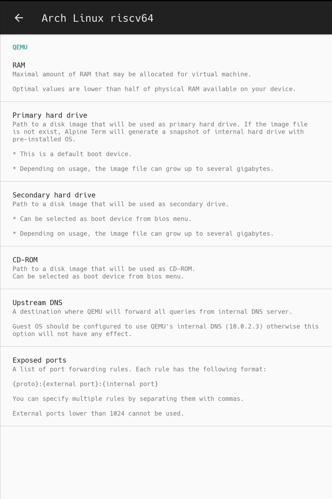

These settings affect options passed to the QEMU. Before changing something, please read description of the each option carefully and understand what you are actually doing. Default values should be good for the most cases.

#### Exiting from application

Arch Linux riscv64 Term is not a regular application. Unless you are in a “sandbox” mode, you cannot safely just close application. There a virtual machine running inside, so before closing the application, it is highly recommended to shut down the virtual machine by either command ‘**poweroff**’ in serial console or command ‘**system_powerdown**’ in QEMU monitor.

Such measures required to prevent loss of data remaining in the buffers. If you forget to do graceful shutdown, you may get a file system left in inconsistent state or even get some files corrupted or lost (worst cases).

by Leonid Plyushch (@xeffyr)

edited by fish4terrisa (@fish4terrisa-MSDSM)